# Mapping Similarity to Make Predictions

by Meg & Becky

It is not much of a secret that people are impressionable. As we grow older everything from our taste in music, religion, food, politics, etc. is conditioned directly or indirectly from the people we interact with. Therefore, it seems reasonable that if two people are similar and one of those people exhibits some measurable behavior, then the other person will probably exhibit a similar behavior when in the same context.

Our aim was to use this concept to make predictions on the score a critic might give for a movie. Our procedure is outlined below, as well our concluding thoughts and takeaways from the endeavour.

## Scraping Procedure

Some helper scraping functions were defined to help organize the scraping procedure. Here they are:

```python
import urllib2
from bs4 import BeautifulSoup as bsoup
from bs4 import Comment
import re
import csv
import pandas
import time

def visible(element):
    if element.parent.name in ['style', 'script', '[document]', 'head', 'title']:
        return False
    elif isinstance(element, Comment):
        return False
    return True

# scrape full review from host site
# returns string
def get_review_text(link, wait_count=0):
    headers = {'User-Agent': 'Mozilla/5.0 (Windows NT 5.1; rv:10.0.1) Gecko/20100101 Firefox/10.0.1', 'content-type':'text/html'}
    request = urllib2.Request(link, headers=headers)

    response = None
    try:
        response = urllib2.urlopen(request)
    except urllib2.HTTPError, e:
        if e.code == 429:
            print "\nERROR 429"
            if wait_count < 5:
                print "Wait "+str(5*wait_count)
                time.sleep(5*wait_count)
                wait_count += 1
                return get_review_text(link, wait_count)
            return None
        else:
            return None
    except:
        return None

    if response.getcode() != 200:
        return None

    html = response.read()

    encoding = response.headers.get("Content-Type")
    if encoding is not None:
        encoding = re.search('charset=(([\w_-])*)', encoding)
        if encoding is not None:
            encoding = encoding.group(1)
        else:
            encoding = None
    if encoding is None:
        encoding = bsoup(html, "html.parser").original_encoding

    soup = bsoup(html.decode(encoding, 'ignore'), "html.parser")

    all_text = soup.findAll(text=True)
    review_text = ""
    for text in all_text:
        if not visible(text): continue

        text = text.encode(encoding, 'ignore')
        if len(re.findall('\w+', text)) > 20:
            review_text = review_text + ' ' + ' '.join(text.split())

    if len(review_text) < 30:
        review_text = None
    return review_text



# scrape starting from critic profile
# returns 5xN rows
def scrape_critic_page(html):

    soup = bsoup(html, "html.parser")

    # get critic name
    critic = soup.find("h1", { "class" : "critic_title" }).getText().encode("utf-8")

    soup = soup.find("ol", { "class" : "reviews critic_profile_reviews" })

    rows = []

    # first review
    first_review = soup.find("li", { "class" : "review critic_review first_review" })
    review_link = first_review.find("li", {"class": "review_action full_review"})
    if review_link is not None:
        title = first_review.find("div", { "class" : "review_product" }).a.getText().encode("utf-8")
        metascore = first_review.find("li", { "class" : "brief_metascore" }).span.getText().encode("utf-8")
        critic_score = first_review.find("li", { "class" : "brief_critscore" }).span.getText().encode("utf-8")
        review_link = review_link.a['href']
        review_text = get_review_text(review_link)
        if review_text is None:
            print "\nERROR"
            print title
        else: rows.append([critic, title, metascore, critic_score, review_text])

    reviews = soup.findAll("li", { "class" : "review critic_review" })

    for review in reviews:

        title = review.find("div", { "class" : "review_product" }).a.getText().encode("utf-8")
        metascore = review.find("li", { "class" : "brief_metascore" }).span.getText().encode("utf-8")
        critic_score = review.find("li", { "class" : "brief_critscore" }).span.getText().encode("utf-8")

        review_link2 = review.find("li", {"class": "review_action full_review"})
        if review_link2 is None:
            print "\nNo Review"
            print title
            continue
        review_link2 = review_link2.a["href"]
        review_text = get_review_text(review_link2)
        if review_text is None:
            print "\nERROR"
            print title
            continue
        rows.append([critic, title, metascore, critic_score, review_text])

        print "\nSUCCESS"
        print title
        print review_link2
        print "TEXT: " + review_text[:15]

    return rows
```

Data was scraped from Metacritic and other websites using the code below.

Note: This code runs for a long time and it will likely lead to errors within the notebook!

```python
try:
    critics = pandas.read_csv('critics2.csv')

    for index, row in critics.iterrows():

        #if index > 400: break
        #if index < 376: continue

        print "PAGE 0\n-----------"

        link = row[0] + "?filter=movies&num_items=100&sort_options=critic_score&page=0"
        row_headers = [["Critic","Title","Metascore","Critic Score", "Review Text"]]

        headers = {'User-Agent': 'Mozilla/5.0', 'content-type':'text/html'}
        request = urllib2.Request(link, headers=headers)
        response = urllib2.urlopen(request)
        html = response.read()

        with open(str(index)+"-0.csv", 'wb') as f:
            writer = csv.writer(f)
            writer.writerows(row_headers + scrape_critic_page(html))

        last_page = bsoup(html, "html.parser").find("li", { "class" : "page last_page" })
        if last_page is None:
            continue

        last_page = int(last_page.a.getText().encode("utf-8"))
        # loop through pages
        for page in range(1,last_page):
            print "PAGE "+str(page)+"\n-----------"
            link = row[0] + "?filter=movies&num_items=100&sort_options=critic_score&page=" + str(page)

            request = urllib2.Request(link, headers=headers)
            try:
                response = urllib2.urlopen(request)
            except urllib2.HTTPError, e:
                if e.code == 429:
                    time.sleep(10)
                    response = urllib2.urlopen(request)


            html = response.read()

            file_name = str(index)+"-"+str(page)+".csv"
            with open(file_name, 'wb') as f:
                writer = csv.writer(f)
                writer.writerows(row_headers + scrape_critic_page(html))

except KeyboardInterrupt:
    print "\nCanceled"
```

Sites hosting review text sometimes require subscriptions or redirect the user to unexpected pages. This leads to the errors being shown in output.

By the end of our data collection we managed to collect 55,000 unique reviews for 189 critics.

## Analysis

Here are some insights we made into the data we collected.

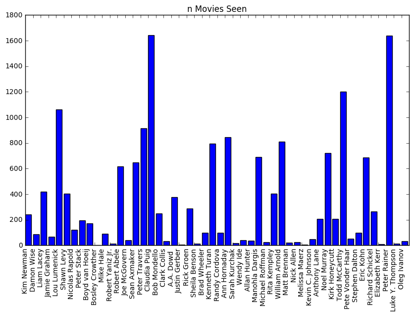

```python
import pandas as pd
import numpy as np
from ast import literal_eval
import networkx as nx
import matplotlib.pyplot as plt
from random import sample

df = pd.read_csv("clean1.csv")

critics_list = df["Critic"].drop_duplicates().values
ran_list = sample(critics_list,50)

n_titles = {}
for critic in ran_list:
    n_titles[critic] = len(df[ df["Critic"]==critic ].drop_duplicates("Title"))

fig = plt.figure(figsize=(10, 6))
plt.title('n Movies Seen')
plt.bar(range(len(n_titles)), n_titles.values())
plt.xticks(range(len(n_titles)), n_titles.keys(), rotation=90)

plt.show()
```

Above is a graph showing the number of movies seen for a list of randomly selected critics. What we immediately realized is that different critics will have seen a largely different amount of movies, and we assumed this is the case for both types of movies and the number of movies.

A graph of the number of shared movies will be shown below.

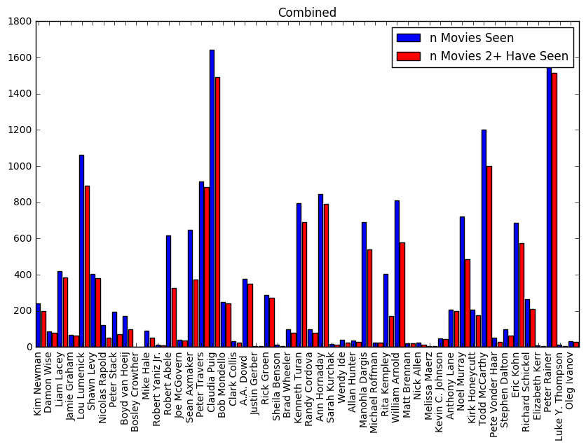

```python
# shared movies matrix
# note: list values are read back as strings!
# convert with ast.literal_eval()
df_shared_adj = pd.read_csv("shared_title_matrix.csv", index_col=0).applymap(literal_eval)

n_shared_titles = {}
for critic1 in ran_list:

    n_shared = set()

    # skip self
    other_critics = list(ran_list)
    other_critics.remove(critic1)

    for critic2 in other_critics:
        n_shared = n_shared.union( set(df_shared_adj[critic1].loc[critic2]) )

    n_shared_titles[critic1] = len(n_shared)

fig = plt.figure(figsize=(10, 6))
plt.title('Combined')
plt.bar(np.arange(len(n_titles)) * 2, n_titles.values(), label='n Movies Seen')
plt.bar(np.arange(len(n_shared_titles)) * 2 + 1, n_shared_titles.values(), color="red", label='n Movies 2+ Have Seen')
plt.legend(loc='upper right')
plt.xticks(np.arange(len(n_shared_titles)) * 2 + 0.5, n_shared_titles.keys(), rotation=90)

plt.show()
```

These differences informed us to make changes in our model which consider the number of movies two particular critics have seen. For instance, for the first model critics which share more movies are weighted higher than those with less. We assumed that having more movies in common increased their similarity and also provides more accuracy when training.

Another interesting observation is that many critics refer to another in some of their reviews. This plays into the notion that people are informed by their respected peers when making judgements, and this supports our focus on critic similarities.

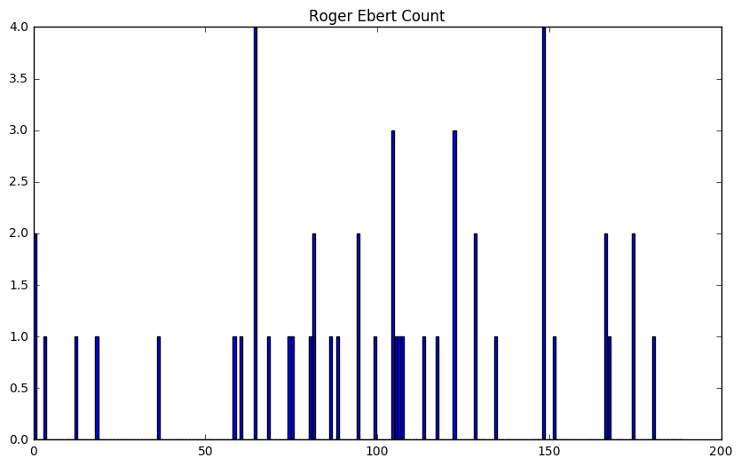

```python
ebert_scores = {}
for critic in critics_list:

    reviews = df[ df["Critic"]==critic ].drop_duplicates("Title")["Review Text"].values

    count = 0
    for review in reviews:
        if "Roger Ebert" in review: count+=1
    ebert_scores[critic] = count

fig = plt.figure(figsize=(10, 6))
plt.title('Roger Ebert Count')
plt.bar(np.arange(len(ebert_scores)), ebert_scores.values())
#plt.xticks(np.arange(len(ebert_scores)), ebert_scores.keys(), rotation=90)

plt.show()
```

Here are the number of reviews that contaiend "Rogert Ebert" for each of the 189 critics. We decided not to work with this information as references of other reviewers was still too sparse for us.

## Model Construction

### Model 1: Critic Score Similarities

In our first intermediate model, critic scores were compared with one another for each shared movie and score differences were taken. These differences between critics were averaged and the modulus was subtracted from a score of 100 and the final result was multiplied by a confidence index based on the number of movie scores compared. The resulting number (between 0 and 100) represents the movie scoring similarity between critics. Each result was stored in an adjacency matrix. Here is the code which generates this matrix:

```python
relationship_matrix = pd.DataFrame(columns=critics_list, index=critics_list)

for i, critic1 in enumerate(critics_list):

    critic1_scores = df[ df["Critic"]==critic1 ]
    critic1_titles = critic1_scores["Title"].values

    similarity_ratios = []
    for critic2 in critics_list:

        if critic1 == critic2:
            similarity_ratios.append(100)
            continue

        critic2_scores = df[ df["Critic"]==critic2 ]
        critic2_titles = critic2_scores["Title"].values

        shared_titles = set(critic1_titles).intersection(set(critic2_titles))
        # add placeholder if no shared movies
        if not len(shared_titles):
            similarity_ratios.append(None)
            continue

        critic1_scores_temp = critic1_scores[ critic1_scores["Title"].isin(shared_titles) ].sort_values(by="Title").reset_index(drop=True)
        critic2_scores = critic2_scores[ critic2_scores["Title"].isin(shared_titles) ].sort_values(by="Title").reset_index(drop=True)

        # make sure we only consider movies with a critic score
        numeric_scores = critic1_scores_temp["Critic Score"].map(np.isreal) & critic2_scores["Critic Score"].map(np.isreal)

        critic1_scores_temp = critic1_scores_temp[ numeric_scores ].reset_index(drop=True)
        critic2_scores = critic2_scores[ numeric_scores ].reset_index(drop=True)

        differences = critic1_scores_temp["Critic Score"] - critic2_scores["Critic Score"]
        differences = differences.apply(abs)
        mean = differences.mean()

        n_shared = len(shared_titles)
        if n_shared >= 30: n_shared = 30

        # log(1)/log(30) = 0 <= confidence_index <= 1 = log( min(n_shared,30) )/log(30)
        confidence_index = math.log(n_shared)/math.log(30)
        mean_difference = 100 - mean
        similarity_ratios.append(mean_difference * confidence_index)

    relationship_matrix.loc[critic1] = similarity_ratios

relationship_matrix.to_csv("critic_score_rel_matrix3.csv")
```

Two extra adjacency matrices were also generated to help compute score predictions. These are the mean critic score differences in one matrix, and the movies that any two critics have seen in the other.

```python
relationship_matrix = pd.DataFrame(columns=critics_list, index=critics_list)

for i, critic1 in enumerate(critics_list):

    critic1_scores = df[ df["Critic"]==critic1 ]
    critic1_titles = critic1_scores["Title"].values

    similarity_ratios = []
    for critic2 in critics_list:

        if critic1 == critic2:
            similarity_ratios.append(100)
            continue

        critic2_scores = df[ df["Critic"]==critic2 ]
        critic2_titles = critic2_scores["Title"].values

        shared_titles = set(critic1_titles).intersection(set(critic2_titles))
        # add placeholder if no shared movies
        if not len(shared_titles):
            similarity_ratios.append(None)
            continue

        critic1_scores_temp = critic1_scores[ critic1_scores["Title"].isin(shared_titles) ].sort_values(by="Title").reset_index(drop=True)
        critic2_scores = critic2_scores[ critic2_scores["Title"].isin(shared_titles) ].sort_values(by="Title").reset_index(drop=True)

        # make sure we only consider movies with a critic score
        numeric_scores = critic1_scores_temp["Critic Score"].map(np.isreal) & critic2_scores["Critic Score"].map(np.isreal)

        critic1_scores_temp = critic1_scores_temp[ numeric_scores ].reset_index(drop=True)
        critic2_scores = critic2_scores[ numeric_scores ].reset_index(drop=True)

        differences = critic1_scores_temp["Critic Score"] - critic2_scores["Critic Score"]
        mean = differences.mean()

        similarity_ratios.append(mean)

    relationship_matrix.loc[critic1] = similarity_ratios

relationship_matrix.to_csv("critic_score_diff_matrix.csv")
```

```python
shared_matrix = pd.DataFrame(columns=critics_list, index=critics_list)

for i, critic1 in enumerate(critics_list):

    critic1_titles = df[ df["Critic"]==critic1 ]

    #print "\n" + critic1 + " - seen movies: " + str(len(critic1_titles))

    shared_titles_list = []

    # use adjacency matrix to get title intersections calculated before
    for critic2 in critics_list[:i]:

        shared_titles_list.append( list(shared_matrix.loc[critic2][critic1]) )

    # for diagonal cell
    shared_titles_list.append( df[ df["Critic"]==critic1 ]["Title"].values.tolist() )

    # get values by calculating
    for critic2 in critics_list[i+1:]:

        critic2_titles = df[ df["Critic"]==critic2 ]

        shared_titles = set(critic1_titles["Title"].values).intersection(set(critic2_titles["Title"].values))

        shared_titles_list.append(list(shared_titles))

    shared_matrix.loc[critic1] = shared_titles_list

shared_matrix.to_csv("shared_title_matrix.csv")
```

To predict the score any critic may give for a particular movie, each of the above adjacency matrices are used. This is done by searching up to 3 of the most similar critics to the critic queried and based on critic score similarity as well as whether the other critic had seen the movie before. These scores are then weighted and combined into a single value which is combined with the mean score difference to the first critic.

```python
# relationship matrix
df_score_adj = pd.read_csv("critic_score_rel_matrix3.csv", index_col=0)
# difference matrix
df_diff_adj = pd.read_csv("critic_score_diff_matrix.csv", index_col=0)

def predict(critic, title):

    # get score if already exists for critic
    # score = df[ (df["Critic"]==critic) & (df["Title"]==title) ]
    # if len(score) != 0:
        # return score.values[0]

    ordered_critics = list(df_score_adj[critic].sort_values(ascending=False).index)
    ordered_critics.remove(critic)

    total_critics = 0
    score_list = []
    for critic2 in ordered_critics:

        if total_critics == 3: break

        shared = df_shared_adj[critic].loc[critic2]

        for string in shared:
            if string == title:
                total_critics+=1
                score_list.append( df[ (df["Critic"]==critic2) & (df["Title"]==title) ].values[0][2] + df_diff_adj[critic].loc[critic2]/2 )

    if total_critics == 1:
        return score_list[0]
    if total_critics == 2:
        weights = [0.8,0.2]
        return sum([a*b for a,b in zip(score_list,weights)])
    if total_critics == 3:
        weights = [0.8,0.1,0.05]
        return sum([a*b for a,b in zip(score_list,weights)])
    else:
        return None
```

### Model 2: WordNet Similarities

The aim of this model is to derive similarity scores based on the synonymic similarity of the language used in one critic's reviews to the language that other reviewers used in their reviews. The NLTK Python module was used to interface with WordNet similarity scores, which were used to gauge word similarity between reviews.

Do not run this code, it takes too long.

```python
clean_csv = df.copy()
clean_csv.columns = ['Critic', 'movie', 'm_score', 'c_score','review_text']

list_ = []
list__ = []
for ii in clean_csv['Critic']:
    list_.append(str(ii))

for jj in clean_csv['review_text']:
    list__.append(str(jj))


new_df = pd.DataFrame(
    {'Critic': list_,
     'values': list__,
    })

name = 'Peter Travers'
all_review = ''
_list = []
__list = []
for index, row in new_df.iterrows():
    if name == row['Critic']:
        all_review += row['values']
    else:
        __list.append(all_review[:15000])
        all_review = ''
        _list.append(name)
        name = row['Critic']

new_new = pd.DataFrame(
    {'Critic': _list,
     'values': __list,
    })

adj_matrix = np.zeros((223,223))

curr_x = 0
curr_y = 0
similarity = 0.0
temp = 0.0

file_name  = 'adj_matrix.csv'


for x in new_new['Critic']:
    curr_y = 0
    for y in new_new['values']:
        if curr_x == curr_y:
            similarity = 1
        else:
            for i in new_new.iloc[curr_x, 1].split(' '):
                word_1_ = wn.synsets(str(i))
                if not len(word_1_) == 0:
                    word_1 = word_1_[0]
                    for j in y.split(' '):
                        word_2_ = wn.synsets(str(j))
                        if not len(word_2_) == 0:
                            word_2 = word_2_[0]
                            temp = wn.path_similarity(word_1,word_2)
                            if not temp == None:
                                similarity += float(temp)

        adj_matrix[curr_x][curr_y] = similarity
        similarity =0.0
        curr_y += 1
    curr_x += 1
    np.savetxt(file_name, adj_matrix, delimiter=",")
    print 'Current reviewer:' +  x;
    print adj_matrix;

adj_df.columns = new_new['Critic'].unique()
adj_df.index = new_new['Critic'].unique()
```

```python
model_2_df = pd.read_csv('clean_matrix_2.csv', header = 0, index_col = 0)

def model2(movie_r , movie_):
    movie_reviewer = movie_r
    movie = movie_
    #adj_df.index = new_new['Critic'].unique()

    movie_df = clean_csv.loc[(clean_csv['movie'] == movie)]

    if len(movie_df) == 0:
    return 50

    p1 = 0.0
    p2 = 0.0
    p3 = 0.0
    p1_n = ''
    p2_n = ''
    p3_n = ''

    for i in movie_df['Critic']:
        temp = adj_df.get_value(i, movie_reviewer)
        if p1 < temp:
            p3 = p2
            p3_n = p2_n
            p2 = p1
            p2_n = p1_n
            p1 = temp
            p1_n = i
        elif p2 < temp:
            p3 = p2
            p3_n = p2_n
            p2 = temp
            p2_n = i
        elif p3 < temp:
            p3 = temp
            p3_n = i

    #print movie_df
    index_ = movie_df[movie_df['Critic'] == p1_n].index.tolist()
    p1_v = movie_df.get_value(index_[0], 'c_score')
    # index_ = movie_df[movie_df['Critic'] == p2_n].index.tolist()
    # p2_v = movie_df.get_value(index_[0], 'c_score')
    # index_ = movie_df[movie_df['Critic'] == p3_n].index.tolist()
    # p3_v = movie_df.get_value(index_[0], 'c_score')

    prediction_val = (p1_v)

    return prediction_val
```

### Model 3: tf-idf vectorization

The tf-idf vectorization is another text model which counts the frequency of words used in reviews and compares those with other critic's reviews. Similarity scores were created based on how well a reviewer's word frequency distribution matched another

Do not run this code, it takes too long.

```python
# # Matrix construction for model 3 using tf-idf vectorization
list_ = []
list__ = []
for ii in clean_csv['Critic']:
    list_.append(str(ii))

for jj in clean_csv['review_text']:
    list__.append(str(jj))


new_df = pd.DataFrame(
    {'Critic': list_,
     'values': list__,
    })
name = 'Peter Travers'
all_review = ''
_list = []
__list = []
for index, row in new_df.iterrows():
    if name == row['Critic']:
        all_review += row['values']
    else:
        __list.append(all_review[:550])
        all_review = ''
        _list.append(name)
        name = row['Critic']

new_new = pd.DataFrame(
    {'Critic': _list,
     'values': __list,
    })


new_new = new_new.loc[(new_new!=0).any(axis=1)]


new_new1 = new_new.loc[(new_new['Critic'] != 'nan')]
new_new1 = new_new1.drop_duplicates('Critic', keep = 'first')

from sklearn.feature_extraction.text import TfidfVectorizer
vect = TfidfVectorizer(min_df=1)
list_ = []
for i in new_new1['values']:
    list_.append(i)

tfidf = vect.fit_transform(list_)
new_mod = (tfidf * tfidf.T).A
```

```python
model_3_df = pd.read_csv('clean_matrix_3.csv', header = 0, index_col = 0)

def model3(movie_r , movie_):
    movie_reviewer = movie_r
    movie = movie_
    movie_df = clean_csv.loc[(clean_csv['movie'] == movie)]

    if len(movie_df) == 0:
    return 50

    p1 = 0.0
    p2 = 0.0
    p3 = 0.0
    p1_n = ''
    p2_n = ''
    p3_n = ''

    for i in movie_df['Critic']:
        temp = model_3_df.get_value(i, movie_reviewer)
        if p1 < temp:
            p3 = p2
            p3_n = p2_n
            p2 = p1
            p2_n = p1_n
            p1 = temp
            p1_n = i
        elif p2 < temp:
            p3 = p2
            p3_n = p2_n
            p2 = temp
            p2_n = i
        elif p3 < temp:
            p3 = temp
            p3_n = i

    #print movie_df
    index_ = movie_df[movie_df['Critic'] == p1_n].index.tolist()
    p1_v = movie_df.get_value(index_[0], 'c_score')
    index_ = movie_df[movie_df['Critic'] == p2_n].index.tolist()
    p2_v = movie_df.get_value(index_[0], 'c_score')
    # index_ = movie_df[movie_df['Critic'] == p3_n].index.tolist()
    # p3_v = movie_df.get_value(index_[0], 'c_score')


    prediction_val = (p1_v)

    if (p1_n == movie_reviewer):
        prediction_val = p2_v

    return prediction_val
```

### Model 4: Metascore

We had also collected Metascore ratings for each film and used these raw scores as part of our prediction. The code below is for getting the score for any particular movie:

```python
def get_metascore(title):

    score = df[ df["Title"]==title ]["Metascore"].values[0]
    if score == "tbd":
        return 60
    else: return int(score)
```

### Combining Models

We combined the predictions of each intermediate model by weighting each and adding them together for a final result. To calculate optimal weights, we fed the result for each model into a linear regression model and trained it on both a 50/50 train-test split and k-fold partitioning.

```python
from sklearn.linear_model import LinearRegression
from sklearn.tree import DecisionTreeClassifier
from sklearn import cross_validation, metrics

def k_fold_val(feature_data, target_data, model=LinearRegression()):

    kfold = cross_validation.KFold(len(feature_data), n_folds=10, shuffle=True, random_state=0)

    rsquared, mean_abs_err, mean_squared_err = 0, 0, 0
    for train_indices, test_indices in kfold:

        train_x, train_y, test_x, test_y = None, None, None, None

        # k-1 training data

        # is dataframe or series
        if isinstance(feature_data, pd.DataFrame) or isinstance(feature_data, pd.Series):
            train_x = feature_data.iloc[train_indices]
            train_y = target_data.iloc[train_indices]

            # test data
            test_x = feature_data.iloc[test_indices]
            test_y = target_data.iloc[test_indices]

        # else np array
        else:
            train_x = feature_data[train_indices]
            train_y = target_data[train_indices]

            # test data
            test_x = feature_data[test_indices]
            test_y = target_data[test_indices]

        model = model.fit(train_x, train_y)

        # estimate for measuring error
        estimates = model.predict(test_x)

        # add metrics to totals
        rsquared = rsquared + model.score(test_x, test_y)
        mean_abs_err = mean_abs_err + metrics.mean_absolute_error(test_y, estimates)
        mean_squared_err = mean_squared_err + metrics.mean_squared_error(test_y, estimates)

    # get averages
    rsquared = rsquared/10
    mean_abs_err = mean_abs_err/10
    mean_squared_err = mean_squared_err/10

    return rsquared, mean_abs_err, mean_squared_err

train_df = pd.read_csv("train.csv", index_col=0)

length = len(train_df)

#train_df["Combined"] = train_df["Model 1"] + train_df["Model 2"] + train_df["Model 3"] / 3

train_features = train_df[["Model 1", "Model 2", "Model 3", "Model 4"]]
#train_features = train_df[["Combined", "Model 4"]]
train_target = train_df["Target"]

lm = LinearRegression()
lm.fit(train_features, train_target)

test_df = pd.read_csv("test.csv", index_col=0)

length = len(test_df)

#test_df["Combined"] = test_df["Model 1"] + test_df["Model 2"] + test_df["Model 3"] / 3

test_features = test_df[["Model 1", "Model 2", "Model 3", "Model 4"]]
#test_features = test_df[["Combined", "Model 4"]]
test_target = test_df["Target"]


print "\nTraining Set Accuracy 50/50: ", lm.score(train_features, train_target)
print "\nTesting Set Accuracy 50/50: ", lm.score(test_features, test_target)

full_df = train_df.append(test_df)

full_features = full_df[["Model 1", "Model 2", "Model 3", "Model 4"]]
full_target = full_df["Target"]

print full_features.shape
print full_target.shape

print "\nFor K-Fold, \n\tR-Squared: %s\n\tMean Absolute Error: %s\n\tMean Squared Error: %s" % k_fold_val(full_features, full_target, LinearRegression())
```

```
Training Set Accuracy 50/50:  0.510196828189

Testing Set Accuracy 50/50:  0.505164567421
(52486, 4)
(52486L,)

For K-Fold,
	R-Squared: 0.50736806331
	Mean Absolute Error: 11.5422539764
	Mean Squared Error: 221.985119906
```

```
According to Model 1, the 5 most similar critics to the rest are:
Peter Rainer
Roger Moore
Ty Burr
Peter Travers
Justin Chang

Here is a graph of 10 critics according to the underlying adjacency matrix (Peter Rainer is included):
```

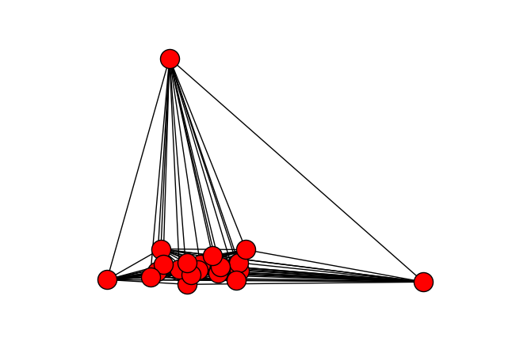

```
According to Model 2, the 5 most similar critics to the rest are:
Jamie Graham
Liam Lacey
Tom Keogh
David Rooney
Farran Smith Nehme

Here is a graph of 10 critics according to the underlying adjacency matrix (Jamie Graham is included):
```

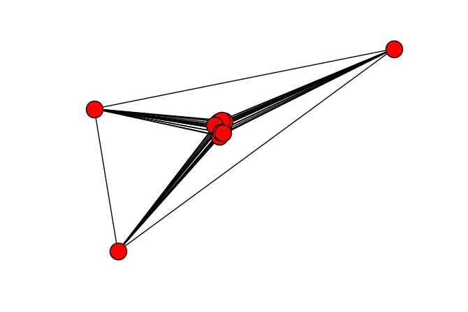

```
According to Model 3, the 5 most similar critics to the rest are:
Alan Scherstuhl
Todd VanDerWerff
Justin Gerber
Shawn Levy
Damon Wise

Here is a graph of 10 critics according to the underlying adjacency matrix (Alan Scherstuhl is included):
```

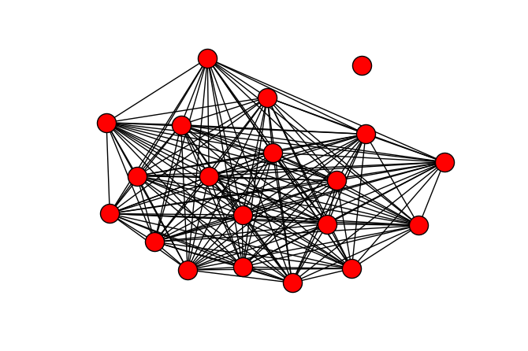

```python
model_2_df = pd.read_csv('clean_matrix_2.csv', header = 0, index_col = 0)
model_3_df = pd.read_csv('clean_matrix_3.csv', header = 0, index_col = 0)

critics_list2 = list(critics_list)
critics_list2.remove("Mike D'Angelo")

"""
score_list = []
c_score = 0.0
for i in model_2_df.columns:
    for j in model_2_df[i]:
        c_score += j
    score_list.append(c_score)
    c_score = 0.0

top_c1 = ''
top_c2 = ''
top_c3 = ''
top_c1_s = 0.0
top_c2_s = 0.0
top_c3_s = 0.0
this_index = 0
for i in score_list:
    if i > top_c1_s:
        top_c3_s = top_c2_s
        top_c3 = top_c2
        top_c2_s = top_c1_s
        top_c2 = top_c1
        top_c1_s = i
        top_c1 = this_index
    elif i > top_c2_s:
        top_c3_s = top_c2_s
        top_c3 = top_c2
        top_c2_s = i
        top_c2_s = this_index
    elif i > top_c3_s:
        top_c3_s = i
        top_c3 = this_index

    this_index += 1
print model_2_df.columns[top_c3], top_c3_s
print model_2_df.columns[top_c2], top_c2_s
print model_2_df.columns[top_c1], top_c1_s

"""

for i, matrix in enumerate([df_score_adj, model_2_df, model_3_df]):
    avg_score = {}
    for critic in critics_list2:
        avg_score[critic] = sum(matrix[critic].dropna().values)/len(critics_list2)

    sorted_critics = sorted(avg_score.items(), key=lambda tup: tup[1], reverse=True)

    print "According to Model %d, the 5 most similar critics to the rest are:" % (i+1)
    for critic in sorted_critics[:5]:
        print critic[0]

    print "\nHere is a graph of 10 critics according to the underlying adjacency matrix (%s is included):" % sorted_critics[0][0]

    idx = matrix.index.get_loc(sorted_critics[0][0])
    first = idx - 10 if (idx-10)>0 else 0
    last = idx + 10 if (idx+10)<len(critics_list2) else len(critics_list2)-1

    graph_mat = matrix.as_matrix()[first:last, first:last]
    g = nx.from_numpy_matrix(graph_mat)
    nx.draw(g)

    plt.show()
```

# Take aways

Through some trial and error we were able to improve our model's accuracy, although the final model is still not strong enough to make good predictions. What we noticed is that adding more observation features produced the most significant results and that refinement through manipulation of existing features was not as powerful as we had anticipated. We believe our focus on the perplexity of our model hindered its potential.

In the future, more raw variables should be collected and analysed. Also, the computation and memory involved in manipulating features made it almost intractable to do reasonable sentiment analysis over all of our review text. Despite our failure to make good predictions, we are extremely optimistic about the viability of this approach. It is our opinion that mapping similarities between groups of people should have tremendous potential for predicting uncertain human behaviors.